# Lab 6

Nicholas Stout

November 8, 2018

# Names

Nicholas Stout (Daniel Tacconi and Isaac Nellans helped pick out the dataset, but didn’t do anything else to help.)

# Summary

This is a data set of several years worth of Kickstarter data. Kickstarter is a website where people can post ideas they need money to find, and other people may donate to their cause. Summary of the variable,s from the Kaggle page:

ID - internal kickstarter id

name - name of project - A project is a finite work with a clear goal that you’d like to bring to life. Think albums, books, or films.

category - category

main_category - category of campaign

currency - currency used to support

deadline - deadline for crowdfunding

goal - fundraising goal - The funding goal is the amount of money that a creator needs to complete their project.

launched - date launched

pledged - amount pledged by “crowd”

state - Current condition the project is in

backers - number of backers

country - country pledged from

usd pledged - amount of money pledged

usd.pledged.real - (No description)

usd goal.real - Goal amount in USD

```r
head(ks_data)
```

```
##           ID                                                       name
## 1 1000002330                            The Songs of Adelaide & Abullah
## 2 1000003930              Greeting From Earth: ZGAC Arts Capsule For ET
## 3 1000004038                                             Where is Hank?
## 4 1000007540          ToshiCapital Rekordz Needs Help to Complete Album
## 5 1000011046 Community Film Project: The Art of Neighborhood Filmmaking
## 6 1000014025                                       Monarch Espresso Bar
##         category main_category currency   deadline  goal
## 1         Poetry    Publishing      GBP 2015-10-09  1000
## 2 Narrative Film  Film & Video      USD 2017-11-01 30000
## 3 Narrative Film  Film & Video      USD 2013-02-26 45000
## 4          Music         Music      USD 2012-04-16  5000
## 5   Film & Video  Film & Video      USD 2015-08-29 19500
## 6    Restaurants          Food      USD 2016-04-01 50000
##              launched pledged      state backers country usd.pledged
## 1 2015-08-11 12:12:28       0     failed       0      GB           0
## 2 2017-09-02 04:43:57    2421     failed      15      US         100
## 3 2013-01-12 00:20:50     220     failed       3      US         220
## 4 2012-03-17 03:24:11       1     failed       1      US           1
## 5 2015-07-04 08:35:03    1283   canceled      14      US        1283
## 6 2016-02-26 13:38:27   52375 successful     224      US       52375
##   usd_pledged_real usd_goal_real
## 1                0       1533.95
## 2             2421      30000.00
## 3              220      45000.00
## 4                1       5000.00
## 5             1283      19500.00
## 6            52375      50000.00
```

```r
str(ks_data)
```

```
## 'data.frame':    378661 obs. of  15 variables:
##  $ ID              : int  1000002330 1000003930 1000004038 1000007540 1000011046 1000014025 1000023410 1000030581 1000034518 100004195 ...
##  $ name            : Factor w/ 375765 levels "","    IT’S A HOT CAPPUCCINO NIGHT  ",..: 332493 135633 364946 344770 77274 206067 293430 69281 284103 290686 ...
##  $ category        : Factor w/ 159 levels "3D Printing",..: 109 94 94 91 56 124 59 42 114 40 ...
##  $ main_category   : Factor w/ 15 levels "Art","Comics",..: 13 7 7 11 7 8 8 8 5 7 ...
##  $ currency        : Factor w/ 14 levels "AUD","CAD","CHF",..: 6 14 14 14 14 14 14 14 14 14 ...
##  $ deadline        : Factor w/ 3164 levels "2009-05-03","2009-05-16",..: 2288 3042 1333 1017 2247 2463 1996 2448 1790 1863 ...
##  $ goal            : num  1000 30000 45000 5000 19500 50000 1000 25000 125000 65000 ...
##  $ launched        : Factor w/ 378089 levels "1970-01-01 01:00:00",..: 243292 361975 80409 46557 235943 278600 187500 274014 139367 153766 ...
##  $ pledged         : num  0 2421 220 1 1283 ...
##  $ state           : Factor w/ 6 levels "canceled","failed",..: 2 2 2 2 1 4 4 2 1 1 ...
##  $ backers         : int  0 15 3 1 14 224 16 40 58 43 ...
##  $ country         : Factor w/ 23 levels "AT","AU","BE",..: 10 23 23 23 23 23 23 23 23 23 ...
##  $ usd.pledged     : num  0 100 220 1 1283 ...
##  $ usd_pledged_real: num  0 2421 220 1 1283 ...
##  $ usd_goal_real   : num  1534 30000 45000 5000 19500 ...
```

```r
summary(ks_data)
```

```
##        ID                                  name
##  Min.   :5.971e+03   New EP/Music Development:    41
##  1st Qu.:5.383e+08   Canceled (Canceled)     :    13
##  Median :1.075e+09   Music Video             :    11
##  Mean   :1.075e+09   N/A (Canceled)          :    11
##  3rd Qu.:1.610e+09   Cancelled (Canceled)    :    10
##  Max.   :2.147e+09   Debut Album             :    10
##                      (Other)                 :378565
##            category           main_category       currency
##  Product Design: 22314   Film & Video: 63585   USD    :295365
##  Documentary   : 16139   Music       : 51918   GBP    : 34132
##  Music         : 15727   Publishing  : 39874   EUR    : 17405
##  Tabletop Games: 14180   Games       : 35231   CAD    : 14962
##  Shorts        : 12357   Technology  : 32569   AUD    :  7950
##  Video Games   : 11830   Design      : 30070   SEK    :  1788
##  (Other)       :286114   (Other)     :125414   (Other):  7059
##        deadline           goal                          launched
##  2014-08-08:   705   Min.   :        0   1970-01-01 01:00:00:     7
##  2014-08-10:   558   1st Qu.:     2000   2009-09-15 05:56:28:     2
##  2014-08-07:   541   Median :     5200   2010-06-30 17:29:43:     2
##  2015-05-01:   489   Mean   :    49081   2011-02-08 04:29:48:     2
##  2014-08-09:   477   3rd Qu.:    16000   2011-02-25 09:58:36:     2
##  2015-07-01:   449   Max.   :100000000   2011-03-03 17:55:38:     2
##  (Other)   :375442                       (Other)            :378644
##     pledged                state           backers
##  Min.   :       0   canceled  : 38779   Min.   :     0.0
##  1st Qu.:      30   failed    :197719   1st Qu.:     2.0
##  Median :     620   live      :  2799   Median :    12.0
##  Mean   :    9683   successful:133956   Mean   :   105.6
##  3rd Qu.:    4076   suspended :  1846   3rd Qu.:    56.0
##  Max.   :20338986   undefined :  3562   Max.   :219382.0
##
##     country        usd.pledged       usd_pledged_real
##  US     :292627   Min.   :       0   Min.   :       0
##  GB     : 33672   1st Qu.:      17   1st Qu.:      31
##  CA     : 14756   Median :     395   Median :     624
##  AU     :  7839   Mean   :    7037   Mean   :    9059
##  DE     :  4171   3rd Qu.:    3034   3rd Qu.:    4050
##  N,0"   :  3797   Max.   :20338986   Max.   :20338986
##  (Other): 21799   NA's   :3797
##  usd_goal_real
##  Min.   :        0
##  1st Qu.:     2000
##  Median :     5500
##  Mean   :    45454
##  3rd Qu.:    15500
##  Max.   :166361391
##
```

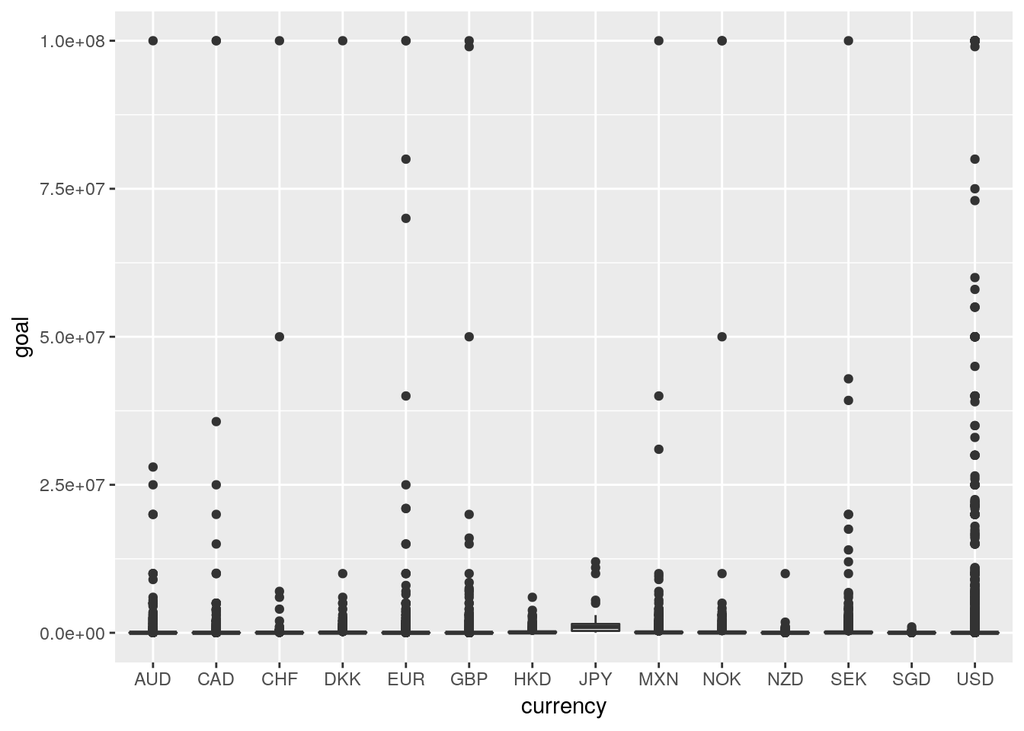

```r
ggplot(ks_data, aes(x=currency, y=goal))+geom_boxplot()
```

```r
max = max(ks_data$goal)
filter(ks_data, goal == 100000000) %>% select(name)
```

```
##                                                            name
## 1               Help me start a fair media company, Trump Media
## 2                      Sage: Warrior Of The Fallen Gods (Movie)
## 3                           Kybernan Holographic Gaming Network
## 4                                               Art Is Fabulous
## 5                                                     Wax Apple
## 6                                            Bring back Pontiac
## 7                              Survival SandBox Game (Canceled)
## 8                                      This Land Called America
## 9                                                    Our future
## 10                                    A New Mathematical System
## 11                                            NAKED FASHION ART
## 12       Let's prove the earth is FLAT! (Suspended) (Suspended)
## 13                           The Return Of The Bell Witch Movie
## 14 The Book on Comedy 10 GABAGILLTRILLBILLIOPLEXIAN!!!!!!!!!!!!
```

[output cut: 22 more lines]

We would like to explore this data to find what effects if a Kickstarter succeeds, looking at amount of time to pledge, the goal amount, and how it is effected by the category.

# cleaning

For cleaning, we would need to fix the date and time objects to the correct datatype. The notes on the last three variables (usd pledged, usd.pledged.real, usd goal.real) are ambiguous about what they are for exactly. Those may need to be converted by hand. ID should probably be converted to a factor as well. It appears there are around 36 with a goal of exactly 100,000,000. That may be the max on the site, however, because the ones I checked were legitimate.